# My Simple Logistic Regression

```r
ti <- TitanicSurvival |>
  mutate(
    survived = case_when(
      survived %in% 'no' ~ 0,
      survived %in% 'yes' ~ 1
    )
  )
```

## Intro/Context

This data set contains information of the survival status of Titanic passengers as well as their age, sex, and ticket class. It has information of 1309 passengers that were in the Titanic disaster back in 1912. This data set is a fragment of a larger data set compiled by Thomas Cason.

For this analysis we replaces the survival status in the following way, Yes = 1 and No = 0. So, if a passenger survived, then the survival status will say 1 instead of Yes. This data set shows information from passengers that range on age from 0.1yrs up to 80yrs.

What is the probability of surviving the Titanic disaster if you were significantly old in age?

## Logistic Regression Equation

$$P(Y_i = 1|\, x_i) = \frac{e^{\beta_0 + \beta_1 x_i}}{1+e^{\beta_0 +
\beta_1 x_i}} = \pi_i$$
Yi = 1 means that the person survived the disaster.

Yi = 0 means that the person didn’t survived the disaster.

xi is the age of the individual who were in the Titanic when the disaster happened.

If beta1 is equal to 0 in the formula above, then older a person was at the Titanic is not a significant indicator of Surviving. If beta1 is not equal to 0, then the age is a significant indicator. Therefore, we will test the following hypothesis.

$$H_0: \beta_1=0$$
$$H_a: \beta_1 \ne 0$$

$$\alpha=0.05$$

## Graphical Summary

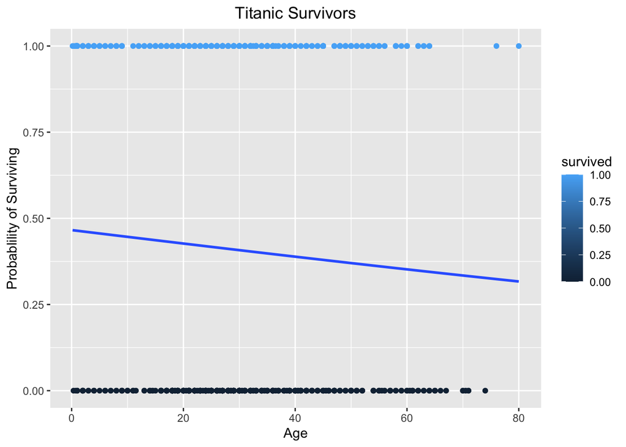

```r
ggplot(data=ti, aes(x=age, y=survived, col=survived))+
    geom_point()+
  geom_smooth(method="glm", method.args=list(family="binomial"), se=FALSE)+
  labs(title="Titanic Survivors", x="Age", y="Probablility of Surviving")+
  theme(plot.title = element_text(hjust = 0.5))
```

From the above plot we can see that the dots at the bottom of the plot seem to be closer to the beginning of the x-axis values. Similarly, the dots at the top seem to be closer to the beginning of the x-axis as well, however, they look a little more spread towards the other side of the plot as they get far form the x-axis beginning. This logistic regression models attempts to further confirm that the data is completely appropriate for the logistic regression test, so we will have to run the Hosmer-Lemeshow Goodness of Fit Test that will be shown after the logistic regression model analysis below.

## Logistic Regression model analysis

```r
ti.glm <- glm(survived>0 ~ age, data=ti, family=binomial)
summary(ti.glm) %>% pander()
```

|  | Estimate | Std. Error | z value | Pr(>\|z\|) |
| --- | --- | --- | --- | --- |
| **(Intercept)** | -0.1365 | 0.1447 | -0.9434 | 0.3455 |
| **age** | -0.007899 | 0.004407 | -1.792 | 0.07306 |

(Dispersion parameter for binomial family taken to be 1 )

| Null deviance: | 1415 on 1045 degrees of freedom |
| --- | --- |
| Residual deviance: | 1411 on 1044 degrees of freedom |

Below is the simple logistical regression line for this analysis model. This numerical summary shows that the β0 is -0.1365 which is the value of the Intercept that estimates β0, and β1 is -0.007899 which is the value of age that estimates β1.

$$P(Y_i = 1|x_i) \approx \frac{e^{-0.1365-0.007899
x_i}}{1+e^{-0.1365-0.007899 x_i}} = \hat{\pi}_i$$

We can see that the p-value is 0.07306. Therefore, using the significance level of 0.05, we can say that we fail to reject the null and conclude that the age is not a good indicator of surviving the Titanic disaster.

As we can see below exp(β1) says that for every 1 change on age the survival rate changes by 0.0078 and that’s exactly what we can see in the graph as the line goes down slowly as it changes by 0.0078 for every 1 change in age as mentioned before based on the odd calculated by the equation 1-exp(b1) as it is shown below.

$$1-exp(-0.007899) = 0.007867885$$

## Check for goodness of fit

The data has some xi replicates with g that represents the number of groups to run the goodness of fit test being 10 which is the standard average for this test.We will run a Hosmer and Lemeshow Goodness of Fit Test to see if this model is a good fit for a logistical regression analysis like this one.

```r
hoslem.test(ti.glm$y, ti.glm$fitted, g=10) |> pander()
```

Hosmer and Lemeshow goodness of fit (GOF) test: `ti.glm$y, ti.glm$fitted`

| Test statistic | df | P value |
| --- | --- | --- |
| 18.29 | 8 | 0.01918 * |

The significance level for this test is 0.05, then as we can see the p-value for the goodness of fit test turned out to be 0.019 which is less than the significance level meaning that the logistic regression model is not a good fit for this the data that we are using for this analysis. We claim that the logistic regression is not appropriate for this analysis.

## Predicting and Outcome

Using the model for this analysis, we will predict the probability of surviving depending on the age of a person.

Below is the prediction for a person that is 25yrs old. As we see, there is a 42% chance of surviving under the conditions for this prediction.

```r
predict(ti.glm, newdata = data.frame(age = 25), type = "response") |> pander()
```

| 1 |
| --- |
| 0.4173 |

If a person is 75yrs old, there is a 32% chance of surviving under the conditions for this prediction.

```r
predict(ti.glm, newdata = data.frame(age = 75), type = "response") |> pander()
```

| 1 |
| --- |
| 0.3254 |